# Lab 6: Color Interference

Paired Theory

**Questions associated with the Lab 6 Canvas quiz are noted in boldface.**

### Color Interference

The abstract of the article “Studies of interference in serial verbal reactions” in the *Journal of Experimental Psychology* reads:

> In this study pairs of conflicting stimuli, both being inherent aspects of the same symbols, were presented simultaneously (a name of one color printed in the ink of another color—a word stimulus and a color stimulus). The difference in time for reading the words printed in colors and the same words printed in black is the measure of interference of color stimuli upon reading words. The interference of conflicting color stimuli upon the time for reading 100 words (each word naming a color unlike the ink-color of its print) caused an increase of 2.3 seconds or 5.6% over the normal time for reading the same words printed in black.

The article reports on the results of a study in which seventy college undergraduates were given forms with 100 names of colors written in black ink, and the same 100 names of colors written in another color (i.e., the word purple written in green ink). The total time (in seconds) for reading the 100 words printed in black, and the total time (in seconds) for reading the 100 words printed in different colors were recorded for each subject. The order in which the forms (black or color) were given was randomized to the subjects.

We seek to address the following research question:

**Does printing the name of colors in a different color increase the time it takes to read the words?**

## Identify the scenario

**1. Should these observations be considered paired or independent? Explain your answer.**

Your answer goes here.

**2. Based on your answer to question 1, is the appropriate observed summary statistic to be used to analyze these data the difference in mean times or the mean difference in times? Explain your answer.**

Your answer goes here.

## Forming Hypotheses

**3. Write out the null hypothesis in words, in the context of this study.**

Your answer goes here.

**4. Write out the alternative hypothesis in proper notation for this study.**

Your answer goes here.

## Summarize and Visualize the Data

Since the original data from the study are not available, I simulated data to match the means and standard deviations reported in the article. We will use these simulated data in the analysis below.

```r
color <- read.csv("data/interference.csv")
head(color)
```

|  | Subj | DiffCol | Black |
| --- | --- | --- | --- |
| 1 | 1 | 39.64 | 37.53 |
| 2 | 2 | 44.26 | 42.02 |
| 3 | 3 | 33.84 | 31.99 |
| 4 | 4 | 53.88 | 39.48 |
| 5 | 5 | 38.94 | 43.09 |
| 6 | 6 | 48.77 | 36.00 |

### Comparison of Letter Color Times

Let’s first visualize the distribution of each of the letter color options.

5. Create two histograms of the following:
- the distribution of reading times for words printed in black `Black`
- the distribution of reading times for words printed in a different color `DiffCol`

```r
## Code for histogram 1: Reading times printed in black


## Code for histogram 2: Reading times printed in a different color
```

### Visualizing the Differences in Times

If you look at the data, you will notice there are three columns: `Subj`, `DiffCol`, and `Black`. There is not, however a column with the differences between the different color read time (`DiffCol`) and the black read time (`Black`). Let’s make a new column with the differences!

```r
color <- color %>%
  mutate(Difference = DiffCol - Black)
head(color)
```

|  | Subj | DiffCol | Black | Difference |
| --- | --- | --- | --- | --- |
| 1 | 1 | 39.64 | 37.53 | 2.11 |
| 2 | 2 | 44.26 | 42.02 | 2.24 |
| 3 | 3 | 33.84 | 31.99 | 1.85 |
| 4 | 4 | 53.88 | 39.48 | 14.40 |
| 5 | 5 | 38.94 | 43.09 | -4.15 |
| 6 | 6 | 48.77 | 36.00 | 12.77 |

Now, let’s visualize the distribution of the differences in the reading times.

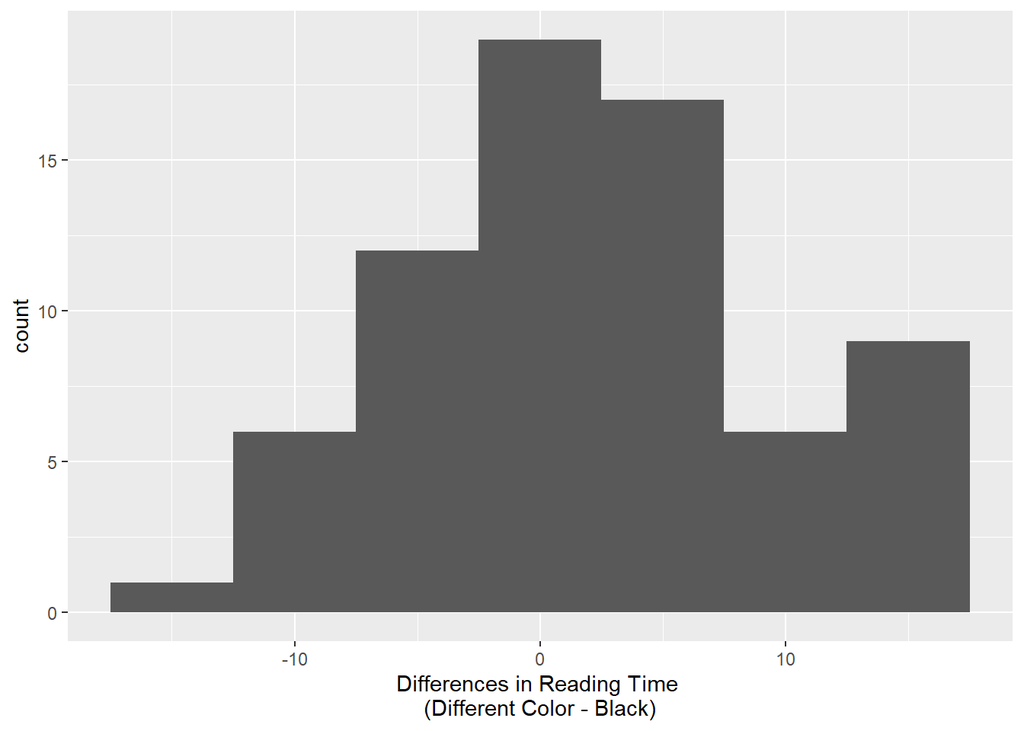

```r
ggplot(data = color,
       mapping = aes(x = Difference)) +
  geom_histogram(binwidth = 5) +
  labs(x = "Differences in Reading Time \n(Different Color - Black)")
```

### Summarizing the Differences in Times

Our final step in the exploratory data anlysis is to calculate summary statistics for the differences in reading times. Using the `Difference` column created above, write the code to obtain summary statistics (using the favstats() function) of the differences in reading time.

```r
# favstats() code goes here
```

**6. What is the observed mean difference in reading times? What notation would you use to denote this?**

Your answer goes here.

## Check Theoretical Conditions

Yesterday, we explored using simulation-based methods to obtain a p-value (permutation) and a confidence interval (bootstrapping). Today, we are going to focus on how we could have obtained these using *theoretical* methods instead.

### The Central Limit Theorem – A Refresher

In general, the sampling distribution for a sample mean, $\bar{x}$, based on a sample of size $n$ from a population with a true mean $\mu$ and true standard deviation $\sigma$ can be modeled using a Normal distribution when certain conditions are not violated.

Conditions for the sampling distribution of $\bar{x}$ to follow an approximate Normal distribution:

- **Independence**: The sample’s observations are independent. For paired data, that means each *difference* should be independent.
- **Normality**: The data should be approximately normal or the sample size should be “sufficiently large.”
  - $n < 30$: If the sample size $n$ is less than 30 and the distribution of the data is approximately normal with no clear outliers in the data, then we typically assume the data come from a population with a nearly normal distribution to satisfy the condition.
  - $n \geq 30$: If the sample size $n$ is at least 30 and there are **no** particularly *extreme* outliers in the data, then we typically assume the sampling distribution of $\bar{x}$ is nearly normal, even if the underlying distribution of individual observations is not.
  - $n \geq 60$: If the sample size $n$ is at least 60 (regardless of the presence of skew or outliers), we typically assume the sampling distribution of $\bar{x}$ is nearly normal, even if the sunderlying distribution of individual observations is not.

**7. How do you know the independence condition is not violated for these data?**

Your answer goes here.

**8. Is the normality condition violated?**

Your answer goes here.

**9. Would it be inappropriate to use theory-based methods for analysis? Explain your answer.**

Your answer goes here.

## Use Statistical Methods to Draw Inferences from the Data

### Mathematical Formulas

To find the standardized statistic for the paired differences we will use the following formula:

$$T = \frac{\bar{x}_\text{color - black} -
0}{SE(\bar{x}_\text{color - black})},$$
where the standard error of the sample mean difference is:

$$SE(\bar{x}_\text{color -
black})=\frac{s_\text{color - black}}{\sqrt{n}}.$$

**10. Calculate the standard error of the sample mean difference.** *(Feel free to use the code block below as a calculator)*

```r
# Example of using R code chunks as a calculator. Replace the 2+2 code with your calculation.

2+2
```

**11. Approximately how many standard errors is the observed mean difference from the null mean difference (null value)?** *Hint: how do you calculate your standardized statistic? (Feel free to use the code block below as a calculator)*

### Using `R` to Obtain a p-value and Confidence Interval

We can use the handy t_test() function from the **infer** package to obtain our p-value for testing if the mean difference is different from 0. Luckily, we can also use this same function to obtain a confidence interval for the mean difference!

I’ve started the code for you, but there are two places you need to fill in values.

- For the blank after *mu*, you need to insert the # we assume the mean difference equals **in the null hypothesis**.
- For the blank after *alternative*, you need to insert what direction R should use when calculating the p-value. Your three choices are: “greater”, “less”, or “two-sided”.
12. Fill in the code with these necessary pieces!

```r
t_test(color, response = Difference,
       mu = ____,
       alternative = "________",
       conf.int = TRUE,
       conf.level = 0.99
      )
```

**13. What is the p-value for this hypothesis test? With an $alpha = 0.01$ what decision would you make?**

Your answer goes here.

**14. What does the p-value you obtained mean, in the context of the study?** *Hint*: it is the probability of what…assuming what?

Your answer goes here.

**15. Report the 99% confidence interval for the mean difference.**

Your answer goes here.

**16. Interpret the confidence interval in context of the study.**

Your answer goes here.

17. Do the results of the CI agree with the p-value? Explain your answer.

Your answer goes here.

18. The abstract states, that the conflicting color stimuli “caused an increase of 2.3 seconds or 5.6% over the normal time for reading the same words printed in black.” Is this statement valid? Explain.

Your answer goes here.